# Verschil tussen fibroblasts met behandeld met BCLXL treatment en fibroblasten behandeld met BCLXL+ONECUT2

# Uitvoeren DGE analyse

```r
# dge analyse
dge_analyse <- DESeq(dds)

# resultaten van dge analyse verkrijgen
# default settings
dge_results <- results(dge_analyse)

# resultaten met een threshold van lfc > 1 en alpha = 0.01
dge_results_lfc1_alpha01 <- results(dge_analyse, lfcThreshold = 1, alpha = 0.01)
```

# Volcano plot opstellen

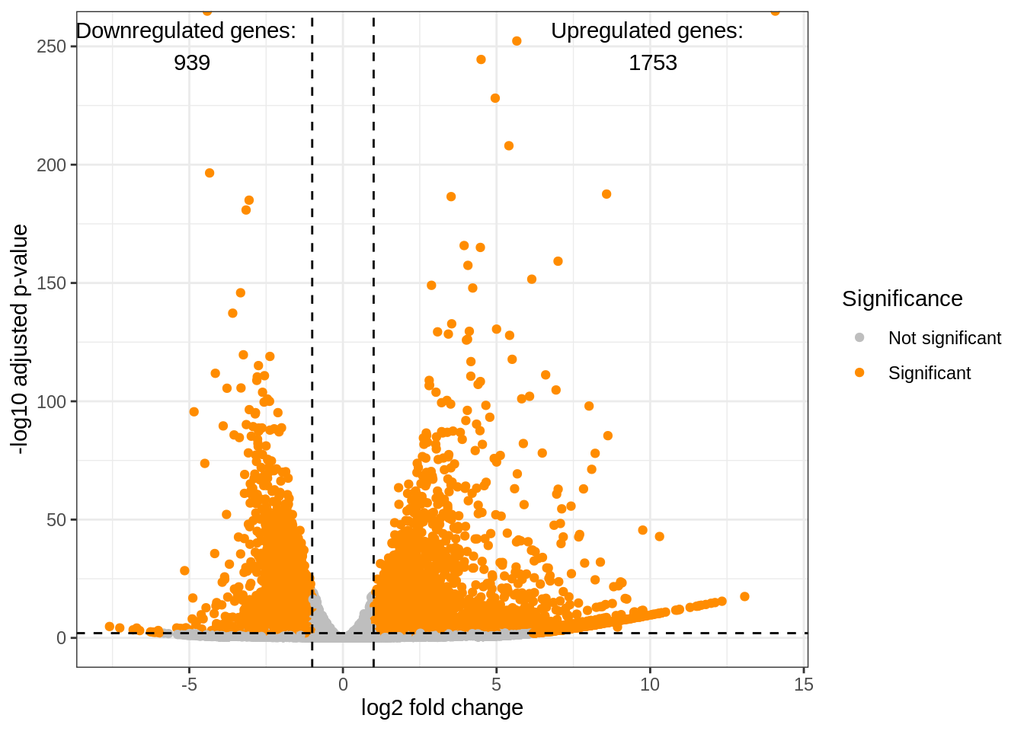

*Figuur 4,* In het figuur staat een volcano plot weergegeven met de log2 foldchange op de X-as tegenover de adjusted P waarde op de Y-as. De genen met een padj kleiner dan 0.01 en een log2 foldchange hoger dan 1 of -1 is oranjegemarkeerd. Zowel het aantal upgereguleerde als downgereguleerde genen staat geannoteerd in het figuur

```r
# Create a dataframe for plotting without genes with padj = NA
dge_plotting <- data.frame(dge_results) %>% filter(!is.na(padj))

# Kolom specificatie wanneer het gen significant verschillend tot expressie komt
dge_plotting <- dge_plotting %>%
  mutate(signif = if_else(padj < 0.01 & abs(log2FoldChange) > 1,
                          "Significant", "Not significant"))

# Aantal significante upregulated genen en significante downregulated genen tellen en opslaan in een variabelen
sign_upregulated_genes <- data.frame(dge_results_lfc1_alpha01) %>% filter(!is.na(padj), padj < 0.01, log2FoldChange > 1) %>% nrow()
sign_downregulated_genes <- data.frame(dge_results_lfc1_alpha01) %>% filter(!is.na(padj), padj < 0.01, log2FoldChange < -1) %>% nrow()

# Maken van een volcano plot
dge_plotting %>%
  ggplot(aes(x = log2FoldChange, y = -log10(padj), color = signif)) +
  geom_point() +
  xlab("log2 fold change") +
  ylab("-log10 adjusted p-value") +
  theme_bw() +

  # Change the legend text and the colours
  scale_colour_manual(values = c("grey", "darkorange"), name = "Significance") +

  # Aantal significante upregulated genen en significante downregulated genen annoteren
  annotate("text", x = -5, y = 250,
           label = paste("Downregulated genes: \n", sign_downregulated_genes), colour = "black")+
  annotate("text", x = 10, y = 250,
           label = paste("Upregulated genes: \n", sign_upregulated_genes), colour = "black")+

  # threshold bepalen door stippellijn
  geom_hline(yintercept = -log10(0.01), linetype = "dashed")+
  geom_vline(xintercept = 1, linetype = "dashed")+
  geom_vline(xintercept = -1, linetype = "dashed")
```

In figuur 4 is de log2 foldchange op X-as tegenover de adjusted P waarde op de Y-as geplot. In het figuur zijn genen met een p-waarde van < 0,01 en een LFC waarde < -1 of > 1 als significant beschouwd. Deze significant beschouwde genen zijn oranje gekleurd en de threshold is met stippelijnen weergegeven. Er is geconcludeerd dat een zeer groot aantal genen een significant verschil in expressie laten zien. Verder is er geconcludeerd dat er meer significante genen zijn waarbij sprake is van upregulatie (1753) ten opzichte van downregulatie (939).